# Solutions 14: Collinearity

Author

Affiliation

Adam Spiegler

University of Colorado Denver

## Additional Reading

- Chapter 10 of *Linear Regression Models: Applications in R* ([link to library ebook](https://go.exlibris.link/Q7wgCRrz))

# Loading Required Packages and Data

```r
library(tidyverse)
library(car)  # compareCoefs and vif functions
library(mctest)  # eigprop function
```

# Motivating Example: Driver Seat Settings

Car drivers like to adjust the seat position for their own comfort. Car designers would find it helpful to know where different drivers will position the seat depending on their size and age. Researchers at the HuMoSim laboratory at the University of Michigan collected data on 38 drivers. They measured `Age` in years, `Weight` in pounds, height with shoes and without shoes on cm (`HtShoes` and `Ht`), seated height `Arm` length (in cm), `Thigh` length (in cm), lower `Leg` length (in cm), and `hipcenter` which is the horizontal distance of the midpoint of the hips from a fixed location in the car in mm.

**Caution**

You do not need to load `faraway` with a `library()` command to load the `seatpos` data frame in the code cell below as long as you have previously installed the `faraway` package. However, if you have not installed the `faraway` package, the code will crash. In which case, run the command `install.packages("faraway")` in the console below. Then run the code cell below.

```r
data(seatpos, package="faraway")
summary(seatpos)
```

```
      Age            Weight         HtShoes            Ht
 Min.   :19.00   Min.   :100.0   Min.   :152.8   Min.   :150.2
 1st Qu.:22.25   1st Qu.:131.8   1st Qu.:165.7   1st Qu.:163.6
 Median :30.00   Median :153.5   Median :171.9   Median :169.5
 Mean   :35.26   Mean   :155.6   Mean   :171.4   Mean   :169.1
 3rd Qu.:46.75   3rd Qu.:174.0   3rd Qu.:177.6   3rd Qu.:175.7
 Max.   :72.00   Max.   :293.0   Max.   :201.2   Max.   :198.4
     Seated            Arm            Thigh            Leg
 Min.   : 79.40   Min.   :26.00   Min.   :31.00   Min.   :30.20
 1st Qu.: 85.20   1st Qu.:29.50   1st Qu.:35.73   1st Qu.:33.80
 Median : 89.40   Median :32.00   Median :38.55   Median :36.30
 Mean   : 88.95   Mean   :32.22   Mean   :38.66   Mean   :36.26
 3rd Qu.: 91.62   3rd Qu.:34.48   3rd Qu.:41.30   3rd Qu.:38.33
 Max.   :101.60   Max.   :39.60   Max.   :45.50   Max.   :43.10
   hipcenter
 Min.   :-279.15
 1st Qu.:-203.09
 Median :-174.84
 Mean   :-164.88
 3rd Qu.:-119.92
 Max.   : -30.95
```

Below we regress `hipcenter` on all other variables in `seatpos`.

```r
# fit model with all predictors
lmod1 <- lm(hipcenter ~ ., data = seatpos)
summary(lmod1)
```

```
Call:
lm(formula = hipcenter ~ ., data = seatpos)

Residuals:
    Min      1Q  Median      3Q     Max
-73.827 -22.833  -3.678  25.017  62.337

Coefficients:
             Estimate Std. Error t value Pr(>|t|)
(Intercept) 436.43213  166.57162   2.620   0.0138 *
Age           0.77572    0.57033   1.360   0.1843
Weight        0.02631    0.33097   0.080   0.9372
HtShoes      -2.69241    9.75304  -0.276   0.7845
Ht            0.60134   10.12987   0.059   0.9531
Seated        0.53375    3.76189   0.142   0.8882
Arm          -1.32807    3.90020  -0.341   0.7359
Thigh        -1.14312    2.66002  -0.430   0.6706
Leg          -6.43905    4.71386  -1.366   0.1824
---
Signif. codes:  0 '***' 0.001 '**' 0.01 '*' 0.05 '.' 0.1 ' ' 1

Residual standard error: 37.72 on 29 degrees of freedom
Multiple R-squared:  0.6866,    Adjusted R-squared:  0.6001
F-statistic:  7.94 on 8 and 29 DF,  p-value: 1.306e-05
```

```r
# create model matrix which includes the intercept
x <- model.matrix(lmod1)
```

## Question 1

Does $R^2$ value of the model seem consistent with the p-values for each coefficient? Why or why not?

### Solution to Question 1

The $R^2$ value is $0.69$ which is indicates a good fit, however, none of the individual predictors is significant.

## Question 2

What are some methods we have use to check for correlations between regressors?

### Solution to Question 2

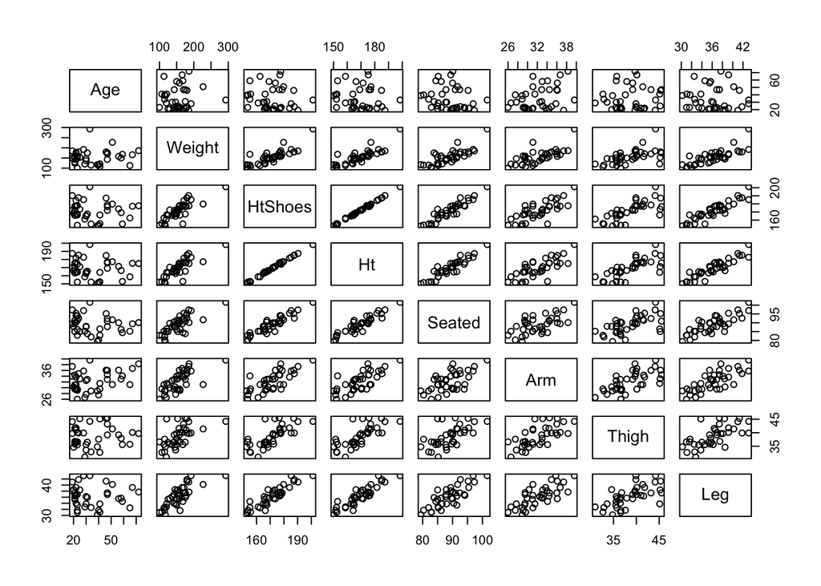

```r
# examine pairwise correlation of predictors
# We exclude hipcenter since its the response
pairs(seatpos[,-9])
```

```r
# examine pairwise correlation
# again we exclude the response hipcenter
round(cor(seatpos[,-9]), 3)
```

```
           Age Weight HtShoes     Ht Seated   Arm Thigh    Leg
Age      1.000  0.081  -0.079 -0.090 -0.170 0.360 0.091 -0.042
Weight   0.081  1.000   0.828  0.829  0.776 0.698 0.573  0.784
HtShoes -0.079  0.828   1.000  0.998  0.930 0.752 0.725  0.908
Ht      -0.090  0.829   0.998  1.000  0.928 0.752 0.735  0.910
Seated  -0.170  0.776   0.930  0.928  1.000 0.625 0.607  0.812
Arm      0.360  0.698   0.752  0.752  0.625 1.000 0.671  0.754
Thigh    0.091  0.573   0.725  0.735  0.607 0.671 1.000  0.650
Leg     -0.042  0.784   0.908  0.910  0.812 0.754 0.650  1.000
```

## Question 3

Do you see any large pairwise correlations? Do these make practical sense in this context?

### Solution to Question 3

It seems there are lots of correlations between regressors which makes sense. For example somebody’s `HtShoes` and `Ht` should be very extremely related to each other.

```r
round(cor(seatpos)[,3:8], 2)
```

```
          HtShoes    Ht Seated   Arm Thigh   Leg
Age         -0.08 -0.09  -0.17  0.36  0.09 -0.04
Weight       0.83  0.83   0.78  0.70  0.57  0.78
HtShoes      1.00  1.00   0.93  0.75  0.72  0.91
Ht           1.00  1.00   0.93  0.75  0.73  0.91
Seated       0.93  0.93   1.00  0.63  0.61  0.81
Arm          0.75  0.75   0.63  1.00  0.67  0.75
Thigh        0.72  0.73   0.61  0.67  1.00  0.65
Leg          0.91  0.91   0.81  0.75  0.65  1.00
hipcenter   -0.80 -0.80  -0.73 -0.59 -0.59 -0.79
```

# Collinearity

Collinearity concerns covariability among the regressors. When the columns of the model matrix $X$ are linearly dependent, then $X^T X$ is singular and there is no unique least squares estimate of $\beta$.

- The columns of $X$ are said to be **exactly collinear** in this case.
- This causes serious problems with estimation and interpretation.

Even when the columns of $X$ are not perfectly dependent, we may still have problems.

## Why is Collinearity Problematic?

Measuring `hipcenter` is difficult. Suppose the measurement error had a standard deviation of 10 mm. Let’s see what happens if we add a little bit of measurement error to the response.

```r
set.seed(1) # allows us to reproduce results

# add a little measurement error
lmod1a <- lm(hipcenter + 10 * rnorm(38) ~ ., data = seatpos)
summary(lmod1a)
```

```
Call:
lm(formula = hipcenter + 10 * rnorm(38) ~ ., data = seatpos)

Residuals:
    Min      1Q  Median      3Q     Max
-92.290 -21.627  -1.701  20.960  61.748

Coefficients:
             Estimate Std. Error t value Pr(>|t|)
(Intercept) 385.64889  174.16204   2.214   0.0348 *
Age           0.78367    0.59632   1.314   0.1991
Weight       -0.01341    0.34605  -0.039   0.9694
HtShoes      -0.68282   10.19747  -0.067   0.9471
Ht           -2.30047   10.59148  -0.217   0.8296
Seated        1.95491    3.93332   0.497   0.6229
Arm          -0.29280    4.07792  -0.072   0.9433
Thigh        -1.32424    2.78124  -0.476   0.6375
Leg          -5.04301    4.92866  -1.023   0.3147
---
Signif. codes:  0 '***' 0.001 '**' 0.01 '*' 0.05 '.' 0.1 ' ' 1

Residual standard error: 39.44 on 29 degrees of freedom
Multiple R-squared:  0.6518,    Adjusted R-squared:  0.5558
F-statistic: 6.786 on 8 and 29 DF,  p-value: 5.207e-05
```

```r
#library(car)  # compareCoefs is from car package
compareCoefs(lmod1, lmod1a, se = FALSE) # compare coefficients
```

```
Calls:
1: lm(formula = hipcenter ~ ., data = seatpos)
2: lm(formula = hipcenter + 10 * rnorm(38) ~ ., data = seatpos)

            Model 1 Model 2
(Intercept)     436     386
Age           0.776   0.784
Weight       0.0263 -0.0134
HtShoes      -2.692  -0.683
Ht            0.601  -2.300
Seated        0.534   1.955
Arm          -1.328  -0.293
Thigh         -1.14   -1.32
Leg           -6.44   -5.04
```

## Question 4

Comment on the changes to the coefficients from Model 1 and Model 2.

### Solution to Question 4

We get a large change in the estimated regression coefficients! However, $R^2$ and standard error of the two models is mostly unchanged. So with some slight error in the response variable, we get a very different model, that seems to fit just as well (judging by $R^2$ and standard error at least).

Collinearity leads to imprecise estimates of $\beta$.

- The signs of the coefficients can be the opposite of what intuition about the effect of the predictors might suggest.
- The standard errors become inflated so it may be difficult to detect significant regression coefficients.
- The fit becomes very sensitive to measurement errors.
  - Small changes in $y$ can lead to large changes in $\hat{\boldsymbol\beta}$.

# Methods for Detecting Collinearity

We have too many variables! We can reduce the collinearity by removing carefully chosen variables in an appropriate order to get a more stable model, and more clear interpretation of the remaining predictors. We should not conclude that the variable(s) we remove from the model are not related to the response.

## Examine the Correlation Matrix

Examine the pairwise correlation matrix of the regressors and look for *large* pairwise correlations.

- Large is a bit subjective, but the larger the correlation among regressors, the more likely it is that you have a collinearity problem.

```r
round(cor(seatpos[,-9]), 3)
```

```
           Age Weight HtShoes     Ht Seated   Arm Thigh    Leg
Age      1.000  0.081  -0.079 -0.090 -0.170 0.360 0.091 -0.042
Weight   0.081  1.000   0.828  0.829  0.776 0.698 0.573  0.784
HtShoes -0.079  0.828   1.000  0.998  0.930 0.752 0.725  0.908
Ht      -0.090  0.829   0.998  1.000  0.928 0.752 0.735  0.910
Seated  -0.170  0.776   0.930  0.928  1.000 0.625 0.607  0.812
Arm      0.360  0.698   0.752  0.752  0.625 1.000 0.671  0.754
Thigh    0.091  0.573   0.725  0.735  0.607 0.671 1.000  0.650
Leg     -0.042  0.784   0.908  0.910  0.812 0.754 0.650  1.000
```

If we want to include `Weight` in our model, then we could say any other regressor with a correlation coefficient $| r | > 0.7$ will be removed from the model. Then we could remove `HtShoes`, `Ht`, `Seated`, and `Leg`.

With multiple linear regression models we need to move beyond bivariate analysis comparing pairs of regressors. To assess multicollinearity, we need to consider whether one regressor is a near linear combinations of a collection of other regressors.

## Regress on Predictors

Let $R_j^2$ denote the $R^2$ value from an auxiliary regression model with $X_j$ as the response variable and all the other variables (excluding the response) as the regressors. The quantity $1-R_j^2$ is called the tolerance.

## Question 5

Run the two code cells below and identify the values of $R_{\rm \texttt{HtShoes}}^2$ and $R_{\rm \texttt{Age}}^2$. How can we use these values to determine whether or not we should include `HtShoes` and/or `Age` in the model for `hipcenter`?

```r
summary(lm(HtShoes ~ Age + Weight + Ht + Seated + Arm + Thigh + Leg, data = seatpos))
```

```
Call:
lm(formula = HtShoes ~ Age + Weight + Ht + Seated + Arm + Thigh +
    Leg, data = seatpos)

Residuals:
     Min       1Q   Median       3Q      Max
-1.40812 -0.35387  0.07312  0.31358  1.55182

Coefficients:
             Estimate Std. Error t value Pr(>|t|)
(Intercept)  0.231451   3.117889   0.074    0.941
Age          0.014462   0.010345   1.398    0.172
Weight      -0.002405   0.006180  -0.389    0.700
Ht           1.001574   0.050206  19.949   <2e-16 ***
Seated       0.048687   0.069858   0.697    0.491
Arm         -0.022155   0.072898  -0.304    0.763
Thigh       -0.060584   0.048551  -1.248    0.222
Leg          0.010946   0.088220   0.124    0.902
---
Signif. codes:  0 '***' 0.001 '**' 0.01 '*' 0.05 '.' 0.1 ' ' 1

Residual standard error: 0.7061 on 30 degrees of freedom
Multiple R-squared:  0.9967,    Adjusted R-squared:  0.996
F-statistic:  1313 on 7 and 30 DF,  p-value: < 2.2e-16
```

```r
summary(lm(Age  ~ Weight + HtShoes + Ht + Seated + Arm + Thigh + Leg, data = seatpos))
```

```
Call:
lm(formula = Age ~ Weight + HtShoes + Ht + Seated + Arm + Thigh +
    Leg, data = seatpos)

Residuals:
    Min      1Q  Median      3Q     Max
-20.395  -6.731  -1.401   7.865  22.950

Coefficients:
            Estimate Std. Error t value Pr(>|t|)
(Intercept) 114.1198    49.0840   2.325 0.027026 *
Weight        0.1371     0.1030   1.332 0.193015
HtShoes       4.2293     3.0252   1.398 0.172357
Ht           -5.2314     3.0989  -1.688 0.101757
Seated       -0.6631     1.1982  -0.553 0.584057
Arm           3.9914     1.0138   3.937 0.000454 ***
Thigh         0.6241     0.8439   0.740 0.465293
Leg          -0.9436     1.4991  -0.629 0.533844
---
Signif. codes:  0 '***' 0.001 '**' 0.01 '*' 0.05 '.' 0.1 ' ' 1

Residual standard error: 12.08 on 30 degrees of freedom
Multiple R-squared:  0.4995,    Adjusted R-squared:  0.3827
F-statistic: 4.277 on 7 and 30 DF,  p-value: 0.002206
```

### Solution to Question 5

We have $R_{\rm \texttt{HtShoes}}^2 = 0.9967$ and $R_{\rm \texttt{Age}}^2 = 0.4995$. This means `HtShoes` is heavily correlated with the other predictors in the model while `Age` is less correlated with the other predictors. We would not gain much new information about `hipscenter` by adding `HtShoes` to a model that already contains all of the predictors.

## The Variance Inflation Factor (VIF)

The effect of collinearity is that the some regression coefficients have a large variance. The variance of $\widehat{\beta}_j$ can be expressed in the form

$$\begin{align}
\mbox{Var}(\widehat{\beta}_j ) &= \frac{ \sum (y_i - \hat{y}_i)^2}{\sum (x_i - \bar{x})^2 (1 - R_j^2)(n-k-1)}\\
&= {\color{blue}{\frac{1}{1-R_j^2}}} \frac{ \sum (y_i - \hat{y}_i)^2}{\sum (x_i - \bar{x})^2 (n-k-1)} \\
&= ({\color{blue}{\mbox{VIF}_j}}) \ \frac{ \sum (y_i - \hat{y}_i)^2}{\sum (x_i - \bar{x})^2 (n-k-1)} .
\end{align}$$

The **variance inflation factor (VIF)** of regressor $j$ is

$$\mbox{VIF}_j = \frac{1}{1-R_j^2}.$$

The larger the correlation of $X_j$ with the other regressors:

- The closer $R_j^2$ is to 1, and thus
- The larger the variance inflation factor, VIF.

**The VIF is the standard diagnostic for assessing collinearity.**

- A $\mbox{VIF}_j$ **more than 10 indicates a potential problem with collinearity** for regressor $X_j$.
- Other more conservative values for the VIF, such as $5$, can be commonly used as well.
- Orthogonality with other predictors implies that $R_j^2=0$ and $\mbox{VIF}_j = 1$, which minimizes the variance of $\widehat{\beta}_j$.

## Question 6

Using the output from Question 5, compute the VIF for `HtShoes` and `Age`.

### Solution to Question 6

We have

```r
1 / (1 - 0.9967)  # VIF for HtShoes
```

```
[1] 303.0303
```

```r
1 / (1 - 0.4995)  # VIF for Age
```

```
[1] 1.998002
```

$$\mbox{VIF}_{\rm HtShoes} = 303.0303 \quad \mbox{and} \quad \mbox{VIF}_{\rm Age} = 1.998002.$$
### Compute VIF with `vif()`

Using the `vif()` function in the `car` package, we can compute the VIF’s of all regressors.

## Question 7

Run the code cell below and then decide which predictors seem to have a problem with collinearity?

```r
#library(car)
vif(lmod1)  # calculate the vifs
```

```
       Age     Weight    HtShoes         Ht     Seated        Arm      Thigh
  1.997931   3.647030 307.429378 333.137832   8.951054   4.496368   2.762886
       Leg
  6.694291
```

### Solution to Question 7

- The variables `HtShoes` and `Ht` are definitely extremely problematic (this makes practical sense).
- The variables `Seated` and `Leg` also have VIF’s that indicate they may have problems with collinearity.

### Interpreting VIF

When interpreting the VIF, it is more practical to interpret the value of $\sqrt{\mbox{VIF}}$ similar to how we typically take the square root of the variance and interpret the standard deviation. $\sqrt{\mbox{VIF}}$ represents the increased width of the 95% CI for the slope $\widehat{\beta}_j$. For instance:

- $\mbox{VIF}_{\rm HtShoes} = 307.4$ suggests that the 95% CI for $\hat{\beta}_{\rm HtShoes}$ is $\sqrt{307.4}=17.5$ times as wide as it would be if the regressors had a correlation of zero (no collinearity).

## Question 8

Play around with model and see what happens when your remove correlated variables.

```r
vif(lmod1)
```

```
       Age     Weight    HtShoes         Ht     Seated        Arm      Thigh
  1.997931   3.647030 307.429378 333.137832   8.951054   4.496368   2.762886
       Leg
  6.694291
```

### Solution to Question 8

```r
# fit a new model with HtShoes removed
# remove other variables as needed
lmod2 <- lm(hipcenter ~ Age + Weight + Ht + Seated + Arm + Thigh + Leg, data = seatpos)
summary(lmod2)
```

```
Call:
lm(formula = hipcenter ~ Age + Weight + Ht + Seated + Arm + Thigh +
    Leg, data = seatpos)

Residuals:
    Min      1Q  Median      3Q     Max
-74.570 -21.565  -5.471  24.739  61.595

Coefficients:
             Estimate Std. Error t value Pr(>|t|)
(Intercept) 435.80897  163.97188   2.658   0.0125 *
Age           0.73678    0.54404   1.354   0.1858
Weight        0.03279    0.32502   0.101   0.9203
Ht           -2.09530    2.64036  -0.794   0.4337
Seated        0.40267    3.67390   0.110   0.9135
Arm          -1.26842    3.83378  -0.331   0.7431
Thigh        -0.98000    2.55332  -0.384   0.7038
Leg          -6.46852    4.63953  -1.394   0.1735
---
Signif. codes:  0 '***' 0.001 '**' 0.01 '*' 0.05 '.' 0.1 ' ' 1

Residual standard error: 37.13 on 30 degrees of freedom
Multiple R-squared:  0.6857,    Adjusted R-squared:  0.6124
F-statistic: 9.351 on 7 and 30 DF,  p-value: 4.157e-06
```

```r
summary(lmod1)
```

```
Call:
lm(formula = hipcenter ~ ., data = seatpos)

Residuals:
    Min      1Q  Median      3Q     Max
-73.827 -22.833  -3.678  25.017  62.337

Coefficients:
             Estimate Std. Error t value Pr(>|t|)
(Intercept) 436.43213  166.57162   2.620   0.0138 *
Age           0.77572    0.57033   1.360   0.1843
Weight        0.02631    0.33097   0.080   0.9372
HtShoes      -2.69241    9.75304  -0.276   0.7845
Ht            0.60134   10.12987   0.059   0.9531
Seated        0.53375    3.76189   0.142   0.8882
Arm          -1.32807    3.90020  -0.341   0.7359
Thigh        -1.14312    2.66002  -0.430   0.6706
Leg          -6.43905    4.71386  -1.366   0.1824
---
Signif. codes:  0 '***' 0.001 '**' 0.01 '*' 0.05 '.' 0.1 ' ' 1

Residual standard error: 37.72 on 29 degrees of freedom
Multiple R-squared:  0.6866,    Adjusted R-squared:  0.6001
F-statistic:  7.94 on 8 and 29 DF,  p-value: 1.306e-05
```

```r
vif(lmod2)
```

```
      Age    Weight        Ht    Seated       Arm     Thigh       Leg
 1.875729  3.628705 23.352154  8.808440  4.482567  2.626556  6.690858
```

**Note**

The VIF is not appropriate for assessing collinearity for sets of related regressors like dummy-variable regressors or polynomial regressors. The **generalized VIF** should be used in these cases.

## Examine the Eigenvalues of $X^TX$.

Eigenvalues provide a measure of joint variability among a set of explanatory variables. Eigenvalues of $X^TX$ close to $0$ indicate high multicollinearity because they correspond to near-linear dependencies among the predictor variables. An eigenvalue of $0$ would denote perfect multicollinearity and a singular matrix $X$.

Let $\lambda_1 \leq \lambda_2 \leq \ldots \leq \lambda_p$ be the eigenvalues of the regressors (including the intercept) ordered from largest to smallest.

- For observational data, when there is a **wide range in the eigenvalues**, this indicates there is a **potential problem with collinearity**.
- When the **condition number** $\kappa= \sqrt{\frac{\lambda_1}{\lambda_p}} \geq 30$ then **there is a potential problem with collinearity**.

```r
# model matrix off all observed regressors values
# except for the intercept column we ignore for
x <- model.matrix(lmod1)[,-1]
lam <- eigen(t(x) %*% x)  #  eigenvalues of X^TX
round(lam$val, 3)
```

```
[1] 3653671.363   21479.480    9043.225     298.953     148.395      81.174
[7]      53.362       7.298
```

```r
# compute condition number
sqrt(lam$val[1] / lam$val[8])
```

```
[1] 707.5491
```

A **condition index** $\kappa_j= \sqrt{\frac{\lambda_1}{\lambda_j}}$ shows the degree of multicollinearity in a regression design matrix.

```r
# compute condition indices
(kappa <- round(sqrt(lam$val[1]/lam$val), 3))
```

```
[1]   1.000  13.042  20.100 110.551 156.912 212.156 261.667 707.549
```

### Using SVD

**Singular values** of $X$ are the square roots of the eigenvalues of $X^TX$.

```r
svd_result <- svd(x) # SVD of model matrix
round(svd_result$d^2, 3)  # square of singular values
```

```
[1] 3653671.363   21479.480    9043.225     298.953     148.395      81.174
[7]      53.362       7.298
```

## Scaling Regressors

Belsley[^1] recommends that when using condition indices to assess collinearity that:

- The intercept be included in your $X$ matrix.
- The columns of $X$ should NOT be centered.
- The columns of $X$ should be scaled (i.e., the standard deviation of each column should be constant).

```r
# scale all variables except hipcenter
seatpos[, -9] <- scale(seatpos[, -9], center = FALSE, scale = TRUE)
head(seatpos)
```

```
        Age    Weight   HtShoes        Ht    Seated       Arm     Thigh
1 1.1824852 1.1129764 1.0755684 1.0767667 1.0544798 1.0998770 1.1507587
2 0.7968922 1.0820604 0.9623809 0.9637906 0.9282080 1.0023809 0.9272118
3 0.5912426 0.6183202 0.8825176 0.8863380 0.9182392 0.7921551 0.9297521
4 0.4884178 1.1438924 1.0933796 1.0913254 1.0777404 1.1394847 1.1202750
5 0.5912426 0.9831291 1.0227092 1.0138728 1.0400804 0.8987914 1.0186628
6 1.2081914 1.0511443 1.0267311 1.0307610 1.0234657 1.0968302 1.0974123
        Leg hipcenter
1 1.1190223  -206.300
2 0.9727095  -178.210
3 0.8399441   -71.673
4 1.1108938  -257.720
5 0.9998044  -173.230
6 1.0133519  -185.150
```

```r
lmod_sc <- lm(hipcenter ~ ., data = seatpos)  # model with scaled regressors
x_sc <- model.matrix(lmod_sc)  # model matrix includes intercept column
lam_sc <- eigen(t(x_sc) %*% x_sc)  # eigenvalues of X^TX
round(lam_sc$val, 6)  # eigenvalues of scaled model
```

```
[1] 327.211383   5.318493   1.107814   0.173072   0.105788   0.051718   0.024337
[8]   0.007151   0.000245
```

```r
# condition indices for scaled model
(kappa_sc <- round(sqrt(lam_sc$val[1]/lam_sc$val), 3))
```

```
[1]    1.000    7.844   17.186   43.481   55.615   79.542  115.953  213.917
[9] 1155.237
```

- The other condition indices $\sqrt{\frac{\lambda_1}{\lambda_j}}$ are worth examining because they may indicate a problem with more than one linear combination of the regressors.
- This does not tell us which regressors may be correlated, only that collinearity is a problem.

### Which Regressors are Leading to Large Condition Indices?

**Variance decomposition proportions** (or variance proportion, VP) can be examined to determine the regressors that are leading to large condition indices. Larger variance decomposition proportions (VP’s) suggest a greater proportion of a variable’s variance is accounted for by other regressors.To determine whether sufficient multicollinearity is present to warrant concern:

- Look for any condition index greater than or equal to $30$.
- If one is identified, look across its row and find any VP that exceeds $0.50$. A condition index greater than or equal to $30$ coupled with a VP greater than or equal to $0.50$ indicates a collinearity or multicollinearity issue that should be analyzed further.

**Note**

If you have not installed the `mctest` package, in the console run the command `install.packages("mctest")`. Then run the command `library(mctest)` to load the package.

- Run `?eigprop` from the console to access help documentation.

```r
#library(mctest)  # make sure mctest has been installed and loaded
eigprop(lmod1, Inter = TRUE, prop = 0.5) #both are default options.
```

```
Call:
eigprop(mod = lmod1, Inter = TRUE, prop = 0.5)

  Eigenvalues        CI (Intercept)    Age Weight HtShoes     Ht Seated    Arm
1      8.8167    1.0000      0.0000 0.0009 0.0002  0.0000 0.0000 0.0000 0.0000
2      0.1437    7.8325      0.0001 0.4847 0.0019  0.0000 0.0000 0.0000 0.0000
3      0.0298   17.1960      0.0070 0.0022 0.3495  0.0000 0.0000 0.0003 0.0000
4      0.0047   43.5183      0.0512 0.0222 0.0836  0.0000 0.0000 0.0051 0.0443
5      0.0029   55.5778      0.0299 0.0455 0.1877  0.0000 0.0000 0.0015 0.4017
6      0.0014   79.5220      0.0922 0.2586 0.1196  0.0001 0.0001 0.0005 0.5149
7      0.0007  116.3704      0.8036 0.1098 0.2440  0.0024 0.0020 0.1298 0.0039
8      0.0002  213.5986      0.0158 0.0009 0.0026  0.0163 0.0148 0.8621 0.0273
9      0.0000 1153.4832      0.0002 0.0752 0.0110  0.9812 0.9831 0.0007 0.0078
   Thigh    Leg
1 0.0000 0.0000
2 0.0002 0.0002
3 0.0014 0.0000
4 0.4639 0.0000
5 0.2873 0.0711
6 0.0022 0.5137
7 0.0455 0.2272
8 0.1197 0.1853
9 0.0797 0.0025

===============================
Row 9==> HtShoes, proportion 0.981239 >= 0.50
Row 9==> Ht, proportion 0.983052 >= 0.50
Row 8==> Seated, proportion 0.862073 >= 0.50
Row 6==> Arm, proportion 0.514875 >= 0.50
Row 6==> Leg, proportion 0.513685 >= 0.50
```

## Question 9

Based condition indices and the variance decomposition proportions in the output above, which regressor should be first? Then continue removing variables until you believe collinearity has been addressed.

### Solution to Question 9

First, note we see that `HtShoes`, `Ht`, `Seated`, `Arm` and `Leg` are involved in the linear dependency of the regressors. Earlier (based on VIF) we determined the variables `HtShoes`, `Ht`, `Seated`, and `Leg` had problems with collinearity.

## Dropping Regressors from our model

```r
# Lets first remove HtShoes
lmod3 <- update(lmod1, . ~ . - HtShoes)
summary(lmod3)
```

```
Call:
lm(formula = hipcenter ~ Age + Weight + Ht + Seated + Arm + Thigh +
    Leg, data = seatpos)

Residuals:
    Min      1Q  Median      3Q     Max
-74.570 -21.565  -5.471  24.739  61.595

Coefficients:
            Estimate Std. Error t value Pr(>|t|)
(Intercept)  435.809    163.972   2.658   0.0125 *
Age           28.661     21.164   1.354   0.1858
Weight         5.303     52.564   0.101   0.9203
Ht          -359.800    453.397  -0.794   0.4337
Seated        36.353    331.685   0.110   0.9135
Arm          -41.632    125.832  -0.331   0.7431
Thigh        -38.578    100.512  -0.384   0.7038
Leg         -238.735    171.232  -1.394   0.1735
---
Signif. codes:  0 '***' 0.001 '**' 0.01 '*' 0.05 '.' 0.1 ' ' 1

Residual standard error: 37.13 on 30 degrees of freedom
Multiple R-squared:  0.6857,    Adjusted R-squared:  0.6124
F-statistic: 9.351 on 7 and 30 DF,  p-value: 4.157e-06
```

```r
# recheck condition indices
eigprop(lmod3)
```

```
Call:
eigprop(mod = lmod3)

  Eigenvalues       CI (Intercept)    Age Weight     Ht Seated    Arm  Thigh
1      7.8201   1.0000      0.0000 0.0012 0.0002 0.0000 0.0000 0.0000 0.0001
2      0.1410   7.4464      0.0001 0.5184 0.0026 0.0000 0.0001 0.0000 0.0004
3      0.0294  16.3187      0.0079 0.0036 0.3478 0.0001 0.0004 0.0000 0.0021
4      0.0046  41.2403      0.0591 0.0199 0.0884 0.0004 0.0060 0.0404 0.4790
5      0.0029  52.3439      0.0307 0.0480 0.1900 0.0000 0.0016 0.4022 0.3016
6      0.0014  75.1896      0.0720 0.2619 0.1057 0.0010 0.0003 0.5109 0.0034
7      0.0006 116.8649      0.8299 0.1291 0.2438 0.0412 0.2582 0.0046 0.0308
8      0.0001 245.3628      0.0004 0.0177 0.0216 0.9572 0.7335 0.0418 0.1826
     Leg
1 0.0000
2 0.0002
3 0.0000
4 0.0001
5 0.0708
6 0.5517
7 0.1428
8 0.2343

===============================
Row 2==> Age, proportion 0.518436 >= 0.50
Row 8==> Ht, proportion 0.957237 >= 0.50
Row 8==> Seated, proportion 0.733470 >= 0.50
Row 6==> Arm, proportion 0.510936 >= 0.50
Row 6==> Leg, proportion 0.551688 >= 0.50
```

```r
# Next remove Seated (Ht is easier to measure?)
lmod4 <- update(lmod3, . ~ . - Seated)
summary(lmod4)
```

```
Call:
lm(formula = hipcenter ~ Age + Weight + Ht + Arm + Thigh + Leg,
    data = seatpos)

Residuals:
    Min      1Q  Median      3Q     Max
-74.272 -21.565  -5.433  25.082  60.937

Coefficients:
            Estimate Std. Error t value Pr(>|t|)
(Intercept)  443.246    146.874   3.018  0.00505 **
Age           28.494     20.769   1.372  0.17993
Weight         5.824     51.508   0.113  0.91071
Ht          -323.352    303.231  -1.066  0.29450
Arm          -43.197    123.010  -0.351  0.72784
Thigh        -41.276     95.885  -0.430  0.66983
Leg         -242.473    165.106  -1.469  0.15202
---
Signif. codes:  0 '***' 0.001 '**' 0.01 '*' 0.05 '.' 0.1 ' ' 1

Residual standard error: 36.54 on 31 degrees of freedom
Multiple R-squared:  0.6856,    Adjusted R-squared:  0.6248
F-statistic: 11.27 on 6 and 31 DF,  p-value: 1.166e-06
```

```r
# recheck condition indices
eigprop(lmod4)
```

```
Call:
eigprop(mod = lmod4)

  Eigenvalues       CI (Intercept)    Age Weight     Ht    Arm  Thigh    Leg
1      6.8258   1.0000      0.0000 0.0016 0.0003 0.0000 0.0001 0.0001 0.0000
2      0.1374   7.0475      0.0002 0.5243 0.0038 0.0001 0.0001 0.0006 0.0003
3      0.0281  15.5795      0.0117 0.0074 0.3539 0.0004 0.0002 0.0042 0.0002
4      0.0042  40.3644      0.1133 0.0077 0.0757 0.0022 0.0215 0.5719 0.0040
5      0.0028  49.3485      0.0743 0.0456 0.2301 0.0003 0.4333 0.2524 0.0622
6      0.0014  70.2968      0.1057 0.2702 0.1176 0.0020 0.5101 0.0037 0.5654
7      0.0003 150.4243      0.6947 0.1432 0.2187 0.9950 0.0347 0.1672 0.3680

===============================
Row 2==> Age, proportion 0.524344 >= 0.50
Row 7==> Ht, proportion 0.994999 >= 0.50
Row 6==> Arm, proportion 0.510137 >= 0.50
Row 4==> Thigh, proportion 0.571912 >= 0.50
Row 6==> Leg, proportion 0.565365 >= 0.50
```

```r
# Next remove Leg
lmod5 <- update(lmod4, . ~ . - Leg)
summary(lmod5)
```

```
Call:
lm(formula = hipcenter ~ Age + Weight + Ht + Arm + Thigh, data = seatpos)

Residuals:
    Min      1Q  Median      3Q     Max
-81.891 -24.368  -0.301  25.935  57.945

Coefficients:
             Estimate Std. Error t value Pr(>|t|)
(Intercept)  489.8678   145.9706   3.356  0.00205 **
Age           31.5434    21.0356   1.500  0.14354
Weight        -0.4743    52.2486  -0.009  0.99281
Ht          -578.0092   253.2137  -2.283  0.02924 *
Arm          -91.7557   120.6056  -0.761  0.45235
Thigh        -24.1190    96.8755  -0.249  0.80498
---
Signif. codes:  0 '***' 0.001 '**' 0.01 '*' 0.05 '.' 0.1 ' ' 1

Residual standard error: 37.19 on 32 degrees of freedom
Multiple R-squared:  0.6637,    Adjusted R-squared:  0.6112
F-statistic: 12.63 on 5 and 32 DF,  p-value: 8.141e-07
```

```r
# recheck condition indices
eigprop(lmod5)
```

```
Call:
eigprop(mod = lmod5)

  Eigenvalues       CI (Intercept)    Age Weight     Ht    Arm  Thigh
1      5.8326   1.0000      0.0000 0.0022 0.0004 0.0000 0.0001 0.0001
2      0.1323   6.6402      0.0003 0.5358 0.0056 0.0002 0.0002 0.0009
3      0.0280  14.4345      0.0132 0.0092 0.3475 0.0007 0.0003 0.0051
4      0.0042  37.4837      0.1417 0.0058 0.1056 0.0041 0.0268 0.5284
5      0.0026  47.7760      0.0290 0.1224 0.1268 0.0000 0.7375 0.3056
6      0.0004 117.0632      0.8157 0.3245 0.4142 0.9950 0.2351 0.1598

===============================
Row 2==> Age, proportion 0.535835 >= 0.50
Row 6==> Ht, proportion 0.995005 >= 0.50
Row 5==> Arm, proportion 0.737508 >= 0.50
Row 4==> Thigh, proportion 0.528443 >= 0.50
```

```r
# Next remove Arm
lmod6 <- update(lmod5, . ~ . - Arm)
summary(lmod6)
```

```
Call:
lm(formula = hipcenter ~ Age + Weight + Ht + Thigh, data = seatpos)

Residuals:
   Min     1Q Median     3Q    Max
-90.21 -24.29   0.61  25.57  53.67

Coefficients:
            Estimate Std. Error t value Pr(>|t|)
(Intercept)   515.66     141.07   3.655 0.000885 ***
Age            21.93      16.71   1.312 0.198419
Weight         -2.68      51.83  -0.052 0.959078
Ht           -672.88     218.97  -3.073 0.004229 **
Thigh         -35.92      95.01  -0.378 0.707797
---
Signif. codes:  0 '***' 0.001 '**' 0.01 '*' 0.05 '.' 0.1 ' ' 1

Residual standard error: 36.95 on 33 degrees of freedom
Multiple R-squared:  0.6576,    Adjusted R-squared:  0.6162
F-statistic: 15.85 on 4 and 33 DF,  p-value: 2.469e-07
```

```r
# recheck condition indices
eigprop(lmod6)
```

```
Call:
eigprop(mod = lmod6)

  Eigenvalues      CI (Intercept)    Age Weight     Ht  Thigh
1      4.8369  1.0000      0.0001 0.0051 0.0006 0.0000 0.0002
2      0.1306  6.0857      0.0004 0.8220 0.0070 0.0003 0.0012
3      0.0279 13.1671      0.0149 0.0130 0.3396 0.0010 0.0060
4      0.0041 34.4990      0.1258 0.0001 0.0678 0.0042 0.6790
5      0.0005 95.5602      0.8588 0.1598 0.5850 0.9945 0.3136

===============================
Row 2==> Age, proportion 0.822025 >= 0.50
Row 5==> Weight, proportion 0.584996 >= 0.50
Row 5==> Ht, proportion 0.994488 >= 0.50
Row 4==> Thigh, proportion 0.679012 >= 0.50
```

```r
# Next remove Weight
lmod7 <- update(lmod6, . ~ . - Weight)
summary(lmod7)
```

```
Call:
lm(formula = hipcenter ~ Age + Ht + Thigh, data = seatpos)

Residuals:
    Min      1Q  Median      3Q     Max
-90.212 -24.233   0.772  25.493  53.754

Coefficients:
            Estimate Std. Error t value Pr(>|t|)
(Intercept)   520.99      94.70   5.501 3.83e-06 ***
Age            21.66      15.64   1.384    0.175
Ht           -681.52     139.49  -4.886 2.41e-05 ***
Thigh         -35.08      92.21  -0.380    0.706
---
Signif. codes:  0 '***' 0.001 '**' 0.01 '*' 0.05 '.' 0.1 ' ' 1

Residual standard error: 36.41 on 34 degrees of freedom
Multiple R-squared:  0.6576,    Adjusted R-squared:  0.6274
F-statistic: 21.77 on 3 and 34 DF,  p-value: 4.774e-08
```

```r
# recheck condition indices
eigprop(lmod7)
```

```
Call:
eigprop(mod = lmod7)

  Eigenvalues      CI (Intercept)    Age     Ht  Thigh
1      3.8721  1.0000      0.0003 0.0089 0.0001 0.0003
2      0.1219  5.6362      0.0022 0.9191 0.0014 0.0025
3      0.0049 28.2359      0.3893 0.0003 0.0002 0.4454
4      0.0012 56.6904      0.6082 0.0717 0.9983 0.5518

===============================
Row 2==> Age, proportion 0.919063 >= 0.50
Row 4==> Ht, proportion 0.998313 >= 0.50
Row 4==> Thigh, proportion 0.551813 >= 0.50
```

```r
# Next remove Thigh (Ht easier to measure)
lmod8 <- update(lmod7, . ~ . - Thigh)
summary(lmod8)
```

```
Call:
lm(formula = hipcenter ~ Age + Ht, data = seatpos)

Residuals:
    Min      1Q  Median      3Q     Max
-91.534 -23.028   2.131  24.994  53.939

Coefficients:
            Estimate Std. Error t value Pr(>|t|)
(Intercept)   526.96      92.25   5.712 1.85e-06 ***
Age            20.27      15.03   1.349    0.186
Ht           -721.28      91.23  -7.906 2.69e-09 ***
---
Signif. codes:  0 '***' 0.001 '**' 0.01 '*' 0.05 '.' 0.1 ' ' 1

Residual standard error: 35.96 on 35 degrees of freedom
Multiple R-squared:  0.6562,    Adjusted R-squared:  0.6365
F-statistic:  33.4 on 2 and 35 DF,  p-value: 7.694e-09
```

```r
# recheck condition indices
eigprop(lmod8)
```

```
Call:
eigprop(mod = lmod8)

  Eigenvalues      CI (Intercept)    Age     Ht
1      2.8878  1.0000      0.0005 0.0172 0.0005
2      0.1101  5.1207      0.0054 0.9548 0.0066
3      0.0021 37.4325      0.9942 0.0280 0.9929

===============================
Row 2==> Age, proportion 0.954846 >= 0.50
Row 3==> Ht, proportion 0.992895 >= 0.50
```

```r
# model with scaled regressors
x8 <- model.matrix(lmod8)
lam8 <- eigen(t(x8) %*% x8)
(kappa8 <- round(sqrt(lam8$val[1]/lam8$val), 3))
```

```
[1]  1.000  5.134 37.350
```

# Wrap-Up

Notice that the $R^2$ for the simpler model is $0.66$, which is very close to the $R^2$ of $0.687$ for the original model, but with 6 fewer predictors!

**You should assess collinearity right after exploratory data analysis and before variable selection.**

- If your regressors are collinear, then all the subsequent inference is suspect and none of the diagnostics require you to fit a model first.
- It is better to remove collinear variables first, then proceed with analysis.

## Why Not Remove `Ht`?

If we remove `Ht`, we are left with just one predictor in the model, `Age`. The $R^2$ value decreases from $0.66$ to $0.0421$. This is not a good model. Moreover, the two predictors `Ht` and `Age` have no clear association with each other, thus including `Ht` does help explain much more of the variability in the response and avoids any issues of correlation with `Age`.

```r
# Next remove Thigh (Ht easier to measure)
lmod9 <- update(lmod8, . ~ . - Ht)
summary(lmod9)
```

```
Call:
lm(formula = hipcenter ~ Age, data = seatpos)

Residuals:
     Min       1Q   Median       3Q      Max
-112.463  -44.846   -4.255   42.208  130.959

Coefficients:
            Estimate Std. Error t value Pr(>|t|)
(Intercept)  -192.96      24.30  -7.940    2e-09 ***
Age            30.98      24.63   1.258    0.217
---
Signif. codes:  0 '***' 0.001 '**' 0.01 '*' 0.05 '.' 0.1 ' ' 1

Residual standard error: 59.18 on 36 degrees of freedom
Multiple R-squared:  0.0421,    Adjusted R-squared:  0.01549
F-statistic: 1.582 on 1 and 36 DF,  p-value: 0.2166
```

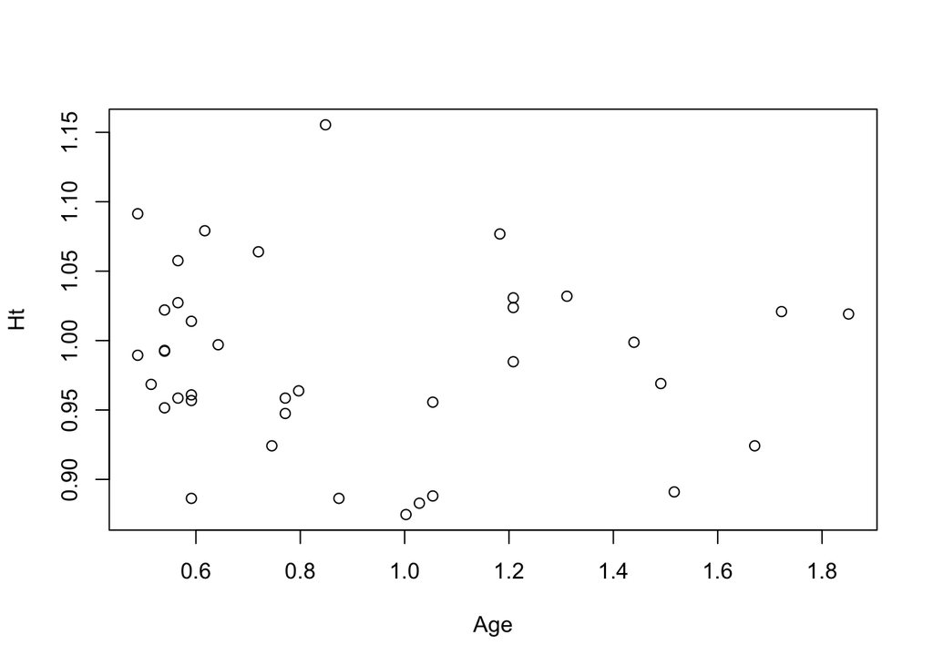

```r
plot(Ht ~ Age, data = seatpos)
```

## Question 10

What methods can be utilized to look for and fix problems with collinearity?

### Solution to Question 10

1. Examine the correlation matrix.
2. Regress one predictor on all others and look at the value of $R_j^2$.
3. The variance inflation factor. A VIF above 5 or 10 indicates a problem with collinearity.
4. Variance decomposition proportions. A variable is involved in the linear dependency if its proportion over the rows with large condition indices is more than 50%.

## Footnotes

[^1]: Belsley, D.A. Computer Science in Economics and Management (1991)